# Course Project - Practical Machine Learning

Dominique Gijzen

21 januari 2017

```r
require("caret")
```

```r
require("ggplot2")
require("caret")
require("corrplot")
```

# get the data

The data is downloaded via the given link and is loaded into R. Upon inspection there seem to be several missing and/or faulty fields. I’ve chosen to classify them as NA’s. This also solves the problem that some of the data are loaded as factors.

```r
trainData <- read.csv("pml-training.csv", na.strings = c("NA", "#DIV/0!"))
testData <- read.csv("pml-testing.csv", na.strings = c("NA", "#DIV/0!"))
```

# prepare the data

The original data sets are copied to a working copy for further analysis.

```r
training <- trainData
testing <- testData
```

## First look

To prepare the data, we will look at a few different aspects of the data. Head, str and summary to start with. To look at these yourself, uncomment next lines.

```r
##head(trainData)
##str(trainData)
##summary(trainData)
```

## ID columns

The first seven colums are used for identification. They serve no good for model training.

```r
dim(training)
```

```
## [1] 19622   160
```

```r
training <- training[, -(1:7)]
dim(training)
```

```
## [1] 19622   153
```

## Missing values

There are lot of missing values. Columns with almost only missing values (more than 90% missing) will be deleted.

```r
dim(training)
```

```
## [1] 19622   153
```

```r
NAColumns <- sapply(training, function(x) mean(is.na(x))) > 0.90
training <- training[, NAColumns==F]
dim(training)
```

```
## [1] 19622    53
```

# Near Zero Variance

In the first look, all columns with few NA’s seemed to have some or more variance. To be sure next code block will check for near zero variance and delete them eventually.

```r
NZV <- nearZeroVar(training)
print(NZV)
```

```
## integer(0)
```

There are no NZV.

## Splitting for cross validation

```r
inTrain <- createDataPartition(training$classe, p = 0.6, list = F)
TrainSet <- training[inTrain, ]
TestSet <- training[-inTrain, ]
```

# explorate the data

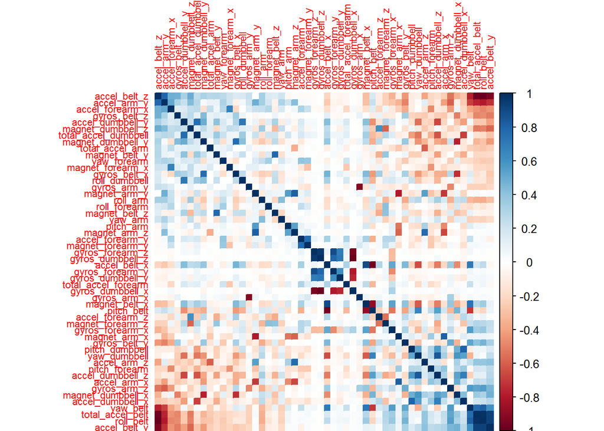

```r
TrainSetCor <- cor(TrainSet[,-53])
corrplot(TrainSetCor, method = "color", order = "FPC", tl.cex = 0.7)
```

The dark colors, red and blue, show strong correlations. There are a few and maybe a principle component analysis can make a difference for the training model. If the model has not enough accuracy, this will be done.

# Training a model

The first model is a decision tree and the second model random forest. Depending on the achieved accuracies when corss validating, a boost model will be used and perhaps a stacked model.

## Decision tree

```r
modDT <- train(classe ~ ., data = TrainSet, method = "rpart")
modDT
```

```
## CART
##
## 11776 samples
##    52 predictor
##     5 classes: 'A', 'B', 'C', 'D', 'E'
##
## No pre-processing
## Resampling: Bootstrapped (25 reps)
## Summary of sample sizes: 11776, 11776, 11776, 11776, 11776, 11776, ...
## Resampling results across tuning parameters:
##
##   cp          Accuracy   Kappa
##   0.03500237  0.5213891  0.38177721
##   0.06039393  0.4228297  0.21920458
##   0.11355007  0.3138180  0.04403479
##
## Accuracy was used to select the optimal model using  the largest value.
## The final value used for the model was cp = 0.03500237.
```

Accuracy is 50% which is not good. Training with another model is necessary.

## Random Forests

```r
modRF <- train(classe ~ ., data = TrainSet, method = "rf")
modRF
```

```
## Random Forest
##
## 11776 samples
##    52 predictor
##     5 classes: 'A', 'B', 'C', 'D', 'E'
##
## No pre-processing
## Resampling: Bootstrapped (25 reps)
## Summary of sample sizes: 11776, 11776, 11776, 11776, 11776, 11776, ...
## Resampling results across tuning parameters:
##
##   mtry  Accuracy   Kappa
##    2    0.9858451  0.9820881
##   27    0.9860208  0.9823106
##   52    0.9755299  0.9690377
##
## Accuracy was used to select the optimal model using  the largest value.
## The final value used for the model was mtry = 27.
```

Accuracy is 98%, which is very good and almost twice the decision tree. Extra tweaking or another model could help. But this is not the intention of this project. Next step is validating/testing the prediction model.

## Validate the model

To validate, and check for out-of-sample error, the given train data was sliced (see above).

```r
predRF <- predict(modRF, newdata = TestSet)
confusionMatrix(predRF, TestSet$classe)
```

```
## Confusion Matrix and Statistics
##
##           Reference
## Prediction    A    B    C    D    E
##          A 2230   15    0    0    0
##          B    0 1492   19    1    0
##          C    2   11 1343   15    2
##          D    0    0    6 1268   10
##          E    0    0    0    2 1430
##
## Overall Statistics
##
##                Accuracy : 0.9894
##                  95% CI : (0.9869, 0.9916)
##     No Information Rate : 0.2845
##     P-Value [Acc > NIR] : < 2.2e-16
##
##                   Kappa : 0.9866
##  Mcnemar's Test P-Value : NA
##
## Statistics by Class:
##
##                      Class: A Class: B Class: C Class: D Class: E
## Sensitivity            0.9991   0.9829   0.9817   0.9860   0.9917
## Specificity            0.9973   0.9968   0.9954   0.9976   0.9997
## Pos Pred Value         0.9933   0.9868   0.9782   0.9875   0.9986
## Neg Pred Value         0.9996   0.9959   0.9961   0.9973   0.9981
## Prevalence             0.2845   0.1935   0.1744   0.1639   0.1838
## Detection Rate         0.2842   0.1902   0.1712   0.1616   0.1823
## Detection Prevalence   0.2861   0.1927   0.1750   0.1637   0.1825
## Balanced Accuracy      0.9982   0.9899   0.9885   0.9918   0.9957
```

Cross validating with the validating set also shows a high accuracy of 99%. We may assume that this model will achieve good accuracy on the given test set -> little out-of-sampple error.